# R Notebook

### Introduction

Explore the following 2 rules in different situations  
1. R4S-like: two measurements (across levels for the same assay) in the same batch have a 4 standard deviation difference (such as one exceeding 2 SD above the mean, and another exceeding 2 SD below the mean). 2. Two or measurements (across levels for the same assay) in the same batch have exceeded 2 standard deviations on the same side of the mean

```r
library(mvtnorm)
library(tidyverse)
freenome_colors <- c('#948DFF', '#1DE3FE', '#BBD532', '#FF9D42',  '#FC2E7B',
                   '#FECDD1')
```

```r
proteins <- 7
controls <- 3
```

#### Rule 2

Let’s write a function for simulating the data

##### Assumptions

```r
single_assay_simulation <- function(correlation = 0.4, n = 20, batches = 1000) {
  mean_vec <- c(rnorm(1), 3 * rnorm(1), 6 * rnorm(1))
  sigma_vec <-
    c(rnorm(1, 1, 0.05), 3 * rnorm(1, 1, 0.05), 5 * rnorm(1, 1, 0.05))
  variance_vec <- sigma_vec ^ 2

  rho <- correlation ## moderate correlation

  cov_matrix <-
    matrix(
      c(
        variance_vec[1],
        rho * sigma_vec[1] * sigma_vec[2],
        rho * sigma_vec[1] * sigma_vec[3],
        rho * sigma_vec[1] * sigma_vec[2],
        variance_vec[2],
        rho * sigma_vec[2] * sigma_vec[3],
        rho * sigma_vec[1] * sigma_vec[3],
        rho * sigma_vec[2] * sigma_vec[3],
        variance_vec[3]
      ),
      nrow = 3,
      ncol = 3
    )

  ## generate spec limits
  measurands <- rmvnorm(n, mean = mean_vec, sigma = cov_matrix)
  sd_limits <- apply(measurands, MARGIN = 2, FUN = sd)

  # Generate 1000 RVs 7 times or generate 7000 RVs?

  sim_measurands <- rmvnorm(batches, mean = mean_vec, sigma = cov_matrix)

  num_times <- sim_measurands %>%
    data.frame() %>%
    rename(x = X1, y = X2, z = X3) %>%
    mutate(
      x_2sd = case_when(x > 2 * sd_limits[1] ~ 1,
                        x < -2 * sd_limits[1] ~ -1,
                        is.double(x) ~ 0),
      y_2sd = case_when(y > 2 * sd_limits[2] ~ 1,
                        y < -2 * sd_limits[2] ~ -1,
                        is.double(y) ~ 0),
      z_2sd = case_when(z > 2 * sd_limits[2] ~ 1,
                        z < -2 * sd_limits[2] ~ -1,
                        is.double(z) ~ 0)
    ) %>%
    mutate(total_sd = x_2sd + y_2sd + z_2sd) %>%
    filter(total_sd >= 2) %>%
    nrow(.) / (batches / 100)
  return(num_times)
}
```

**Iteration over multiple correlations and initial data generation**

```r
parameters <- tidyr::crossing(correlation = seq(0.2, 0.8, by = 0.1),
                n = seq(10, 25, by = 2))
```

```r
iterate_over_params <- function(params = parameters, i = 1) {
  imap_dbl(1:1000, ~single_assay_simulation(correlation = parameters$correlation[i],
                                            n = parameters$n[i])) %>%
    mean()
}


fps <- imap_dbl(1:nrow(parameters), ~ iterate_over_params(params = parameters,
                                                   i = .x))
```

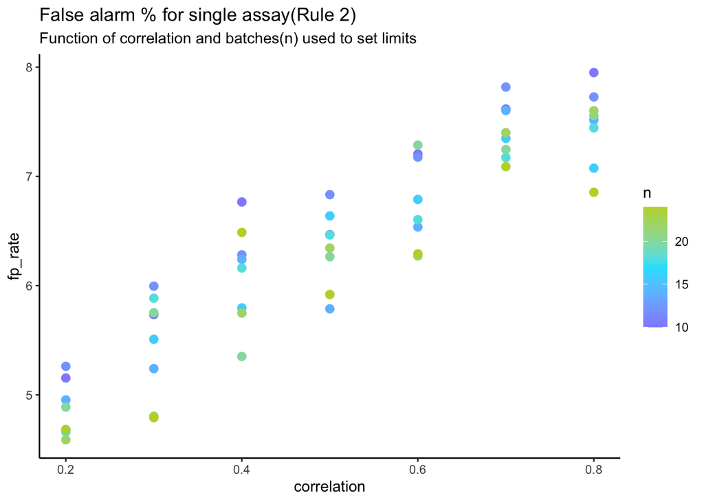

```r
fps %>%
  data.frame() %>%
  janitor::clean_names() %>%
  rename(fp_rate = x) %>%
  bind_cols(parameters) %>%
  ggplot(.,aes(correlation, fp_rate)) +
  geom_point(aes(color = n),
             size = 2.5) +
  scale_color_gradientn(colors = c(freenome_colors[1], freenome_colors[2], freenome_colors[3])) +
  theme_classic() +
  labs(title = "False alarm % for single assay(Rule 2)",
       subtitle = "Function of correlation and batches(n) used to set limits")
```

#### Rule 1

We will count the number of times any of these occurs

1. X > 2SD and Y < 2SD
2. X > 2SD and Z < 2SD
3. X < 2SD and Y > 2SD
4. X < 2SD and Z > 2SD
5. Y < 2SD and Z > 2SD
6. Y > 2SD and Z < 2SD

```r
r4s_assay_simulation <-
  function(correlation = 0.4,
           n = 20,
           batches = 1000) {
    mean_vec <- c(rnorm(1), 3 * rnorm(1), 6 * rnorm(1))
    sigma_vec <-
      c(rnorm(1, 1, 0.05), 3 * rnorm(1, 1, 0.05), 5 * rnorm(1, 1, 0.05))
    variance_vec <- sigma_vec ^ 2

    rho <- correlation ## moderate correlation

    cov_matrix <-
      matrix(
        c(
          variance_vec[1],
          rho * sigma_vec[1] * sigma_vec[2],
          rho * sigma_vec[1] * sigma_vec[3],
          rho * sigma_vec[1] * sigma_vec[2],
          variance_vec[2],
          rho * sigma_vec[2] * sigma_vec[3],
          rho * sigma_vec[1] * sigma_vec[3],
          rho * sigma_vec[2] * sigma_vec[3],
          variance_vec[3]
        ),
        nrow = 3,
        ncol = 3
      )

    ## generate spec limits
    measurands <- rmvnorm(n, mean = mean_vec, sigma = cov_matrix)
    sd_limits <- apply(measurands, MARGIN = 2, FUN = sd)

    # Generate 1000 RVs 7 times or generate 7000 RVs?

    sim_measurands <-
      rmvnorm(batches, mean = mean_vec, sigma = cov_matrix)


    num_times <- sim_measurands %>%
      data.frame() %>%
      rename(x = X1, y = X2, z = X3) %>%
      mutate(
        x_2sd = case_when(x > 2 * sd_limits[1] ~ 1,
                          x < -2 * sd_limits[1] ~ -1,
                          is.double(x) ~ 0),
        y_2sd = case_when(y > 2 * sd_limits[2] ~ 1,
                          y < -2 * sd_limits[2] ~ -1,
                          is.double(y) ~ 0),
        z_2sd = case_when(z > 2 * sd_limits[2] ~ 1,
                          z < -2 * sd_limits[2] ~ -1,
                          is.double(z) ~ 0)
      ) %>%
      mutate(
        sd_4_opposite = case_when(
          x_2sd == 1 & y_2sd == -1 ~ "yes",
          x_2sd == 1 &
            z_2sd == -1 ~ "yes",
          x_2sd == -1 &
            y_2sd == 1 ~ "yes",
          x_2sd == -1 &
            z_2sd == 1 ~ "yes",
          y_2sd == -1 &
            z_2sd == 1 ~ "yes",
          y_2sd == 1 &
            z_2sd == -1 ~ "yes"
        )
      ) %>%
      filter(sd_4_opposite == "yes") %>%
      nrow(.) / (batches / 100)

    return(num_times)

  }
```

```r
r4s_iterate_over_params <- function(params = parameters, i = 1) {
  imap_dbl(1:1000, ~r4s_assay_simulation(correlation = parameters$correlation[i],
                                            n = parameters$n[i])) %>%
    mean()
}


r4s_fps <- imap_dbl(1:nrow(parameters), ~ r4s_iterate_over_params(params = parameters,
                                                   i = .x))
```

R4S-like: two measurements (across levels for the same assay) in the same batch have a 4 standard deviation difference (such as one exceeding 2 SD above the mean, and another exceeding 2 SD below the mean). Two or measurements (across levels for the same assay) in the same batch have exceeded 2 standard deviations on the same side of the mean.

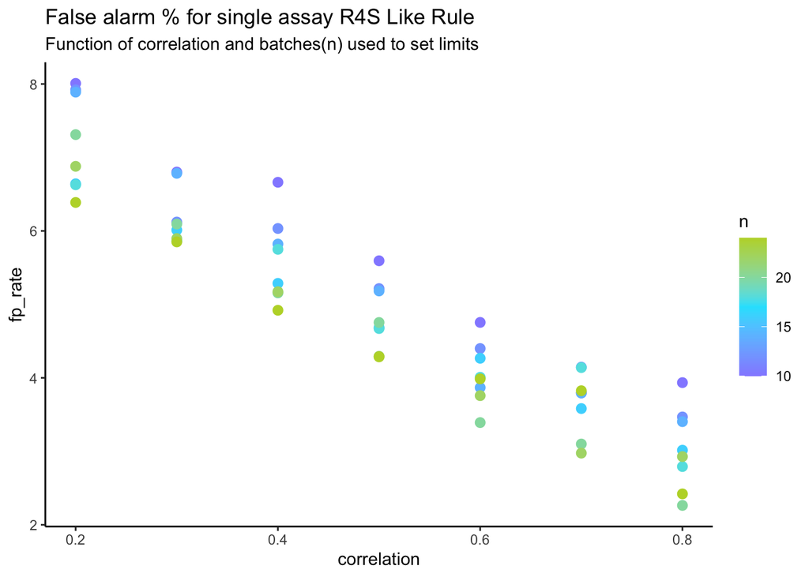

```r
r4s_fps %>%
  data.frame() %>%
  janitor::clean_names() %>%
  rename(fp_rate = x) %>%
  bind_cols(parameters) %>%
  ggplot(.,aes(correlation, fp_rate)) +
  geom_point(aes(color = n),
             size = 2.5) +
  scale_color_gradientn(colors = c(freenome_colors[1], freenome_colors[2], freenome_colors[3])) +
  theme_classic() +
  labs(title = "False alarm % for single assay R4S Like Rule",
       subtitle = "Function of correlation and batches(n) used to set limits")
```